# MiniProject1: Salary Returns to College Grads

Dalia Castro and Yichuan Yan

2/9/2018

### Introduction

Here at Swarthmore College the sophomore plan, the short statement declaring a major/minor choice, for the class of 2020 was recently due. For some, this plan showcases their meticulously thought-out life decision to pursue a career in finance, pre-med, or the like. Meanwhile, for many previously undeclared and unapologetically curious, the clock has struck midnight. The time to choose a path in life has arrived. For those who satisfy the latter group, making the decision at this time in their college career entails confronting the questions they have postponed until now – What would I want to do for a living? How can I pay back my student loans? Should I pick a major based on passion or practicality? Considering that we cannot give a straightforward answer to the former two questions, the emphasis of this blogpost will tackle the last two questions, questions that you might have asked yourself at some point in time. In order to examine college students’ major selection and their ensuring careers, we have recruited help from the US Census Bureau’s [American Community Survey](https://fivethirtyeight.com/features/the-economic-guide-to-picking-a-college-major/) and the [New York Federal Reserve](https://www.newyorkfed.org/research/college-labor-market/college-labor-market_compare-majors.html) data on recent college graduates.

### Recent Graduate Unemployment

We ranked each major by its post-graduation unemployment rate, which represents the ratio of unemployed graduates over all graduates surveyed (both employed and unemployed). According to this ranking, Mass Media seems to be a major with the worst future prospect (no offense to Mass Media majors), while elementary teachers find jobs quite easily post-graduation. Recognizing that career prospect is not just about your first job, we also included wage growth that tracks the percentile change between entry level and mid-career wages. Interestingly, we found that graduates of low prospect majors (as measured by post-graduation unemployment rate) earn an income that benefits from higher growth over time (a whopping 90% for biology majors!), while majors that enjoy job security won’t see much change in their income. There are exceptions to this rule. For example, Physics majors have a high wage growth for a relativly low unemployment rate. However, the overall trend do suggests that **graduates who take risks in their early career might get compensated more over time**, something that you probabily didn’t consider when picking a college!

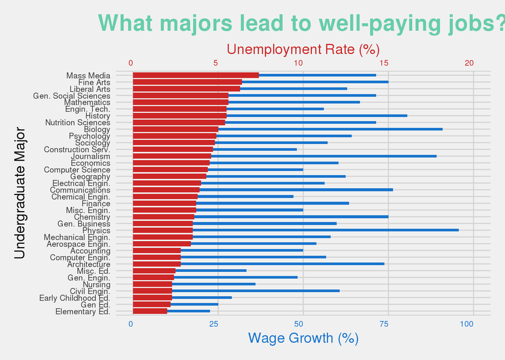

[Source: New York Federal Reserve & U.S. Census Bureau]

### Opportunity Outcomes for Women

Given that there are particular majors that seem to guarantee a good life overall, one has to wonder - does everybody have access to the same kind of economic opportunity? In terms of gender distribution, not all majors are created equal. The plot above showcases what seems to be an amalgam of women in education and social science degrees in contrast with the minimal representation in engineering degrees. How can we explain this given that gender ratio for college enrollment has leveled off since at least the early 2000’s as per the [Economic Policy Institute 2016](https://www.epi.org/publication/class-of-2016/)? There are a few hypothesis to this question. First, throughout their academic life women are conditioned to believe that they are not intelligent, confident enough to pursue a degree in high return majors, particularly STEM. And two, women continue to be underrepresented in certain majors because they take note that there is low representation and are afraid of feeling unwelcome.

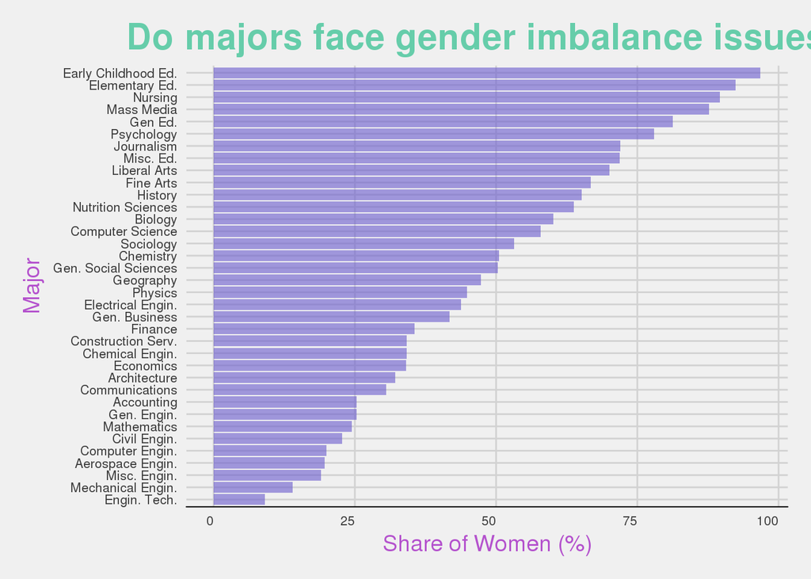

[Source: New York Federal Reserve & U.S. Census Bureau]

### Discussion

This blogpost is about the economic outcomes for different college majors, a subject that we admit may not be relatable to the entirety of the labor market. Indeed, not all of those who are employed studied at a college or university. However, it is important to understand that many high paying jobs in the market today may require a college degree. Although our data shows that there are high returns for some specific college majors, not all of them guarantee the wage trajectory over a lifetime. For example, a higher saturation of employable graduates may increase competition for said jobs and thus over a long-term reduce reduce wages as more and more people seek out the job and employers have more choice and control over the worker pay. That is to say - what the data says today, may not be the same in the future. Consider this before making your decision, as all pertinent decisions in life must be well thought-out!